# construct scales

Alejandra Garcia Isaza

2023-02-28

##### PARENT WAVE 1

# Loading the dataset parent wave 1

```r
parent_w1 <- read_sav(here("outcomes paper/data_outcomes", "primary_parent_w1.sav")) # This dataset has primary parents in wave 1 with most data waves (n = 95)
```

alpha internal consistencies benchmarks .00 to .69 = Poor reliability  
.70 to .79 = Fair reliability  
.80 to .89 = Good reliability  
.90 to .99 = Excellent/Strong reliability

# Parenting Dimensions in JCCP NF paper

- Positive parental involvement
- Monitoring
- Homework engagement
- Skill encouragement (not present)
- Appropriate discipline

## General parenting (not present)

- Positive parental involvement (JCCP paper)* “Positive involvement was an average summative index of parent responses to 21 questions that reflected whether parents had engaged in a variety of positive activities with the target youth during the past week (e.g., gave him or her a hug or kiss, played a game with him or her, went for walk together, talked for at least 10 min about activities in his or her life, enjoyed music together, etc.). The scale demonstrated adequate internal consistency for mother and father scores (Cronbach’s alphas were .83 and .82, respectively).” (p. 846)

*this scale not included as it was in LYFEII. Some items may be similar.

Juntos items, fam activities: 1. Trabajamos en un pasatiempo o artesanía. 2. Participamos en una actividad al aire libre. 3. Leímos o hablamos acerca de un libro o historia. 4. Fuimos a un evento de entretenimiento. 5. Participamos en otras actividades (Fuimos al parque, nadamos, excursión a pie, etc.). 6. Horneamos o cocinamos una comida. 7. Hicimos ejercicio o jugamos un juego al aire libre (baloncesto o béisbol, etc.) 8. Trabajamos alrededor de la casa o patio. 9. Fuimos a la Iglesia, sinagoga, u otro servicio religioso.

```r
# fam_act <- parent_w1 %>%
#   select(q1, q2, q3, q4, q5, q6, q7, q8, q9)
#
# alpha(fam_act) # 0.54 poor (0.55 if all caregivers included)
```

Alternatively (I LIKE THESE BETTER):

116. Cuando mi joven me pide hablar o cuando necesita hablar conmigo, escucho atentamente.
117. Sé escuchar atentamente, aun cuando no esté de acuerdo con lo que dice la otra persona.
118. Con regularidad, mi joven y yo hacemos cosas juntos que ambos disfrutamos
119. Mi joven y yo tenemos una relación cercana
120. Hago y digo cosas que le muestran a mi joven que a él / ella me importa y que yo la/lo amo (por ejemplo, diciendo cosas cariñosas, abrazándole/la, etc.)
121. Como madre/padre, es mi trabajo reconocer y apoyar las fortalezas de mi joven

```r
posi_rel <- parent_w1 %>%
  select(q116, q117, q118, q119, q120, q121) # NO EFA here, just face value.

alpha(posi_rel) # 0.91 (0.90 if all caregivers included)
```

```
##
## Reliability analysis
## Call: alpha(x = posi_rel)
##
##   raw_alpha std.alpha G6(smc) average_r S/N   ase mean   sd median_r
##       0.91      0.91    0.91      0.64  11 0.013  3.3 0.48     0.63
##
##     95% confidence boundaries
##          lower alpha upper
## Feldt     0.88  0.91  0.94
## Duhachek  0.89  0.91  0.94
##
##  Reliability if an item is dropped:
##      raw_alpha std.alpha G6(smc) average_r S/N alpha se  var.r med.r
## q116      0.89      0.89    0.89      0.63 8.5    0.017 0.0079  0.62
## q117      0.91      0.91    0.90      0.67 9.9    0.015 0.0060  0.67
## q118      0.91      0.90    0.89      0.65 9.5    0.015 0.0053  0.64
## q119      0.89      0.89    0.87      0.62 8.0    0.018 0.0057  0.62
## q120      0.89      0.89    0.88      0.62 8.0    0.018 0.0062  0.61
## q121      0.91      0.91    0.89      0.66 9.6    0.015 0.0055  0.64
##
##  Item statistics
##       n raw.r std.r r.cor r.drop mean   sd
## q116 95  0.86  0.86  0.82   0.79  3.3 0.59
## q117 95  0.78  0.78  0.72   0.69  3.2 0.54
## q118 94  0.81  0.81  0.76   0.72  3.2 0.58
## q119 95  0.88  0.88  0.87   0.83  3.3 0.57
## q120 95  0.89  0.88  0.87   0.83  3.4 0.63
## q121 93  0.80  0.80  0.75   0.71  3.4 0.56
##
## Non missing response frequency for each item
##         1    2    3    4 miss
## q116 0.01 0.03 0.58 0.38 0.00
## q117 0.00 0.05 0.66 0.28 0.00
## q118 0.01 0.06 0.67 0.26 0.01
## q119 0.01 0.02 0.62 0.35 0.00
## q120 0.02 0.01 0.48 0.48 0.00
## q121 0.01 0.00 0.53 0.46 0.02
```

# From my diss:

- Monitoring

“Monitoring. Five items reflecting the level of parent’s endorsement of their tracking of their youth’s activities, where they are, and who are they with when they are not at home were used to measure parent’s monitoring of their youth. Sample items included statements such as “I often talk with my youth about their plans for the next day,” and “in general I know who my youth is with.” Response options used a Likert scale that ranged from (1) “strongly disagree” to (4) “strongly agree.” (α = .62).”

137. A menudo hablo con mi joven acerca de sus planes para el día siguiente
138. A menudo hablo con mi joven acerca de sus amigos.
139. Conozco muy bien a los amigos de mi joven.
140. Por lo general yo sé con quién está mi joven
141. Sé lo que hace mi joven y dónde va cuando no está en casa

Not included bec. appear to tap on different ideas: 138. Hablo con mi joven en muchas ocasiones acerca de lo que él / ella aprendió en la escuela 141. Los amigos de mi joven tienen una buena influencia en su vida. 142. Los amigos de mi joven se apoyan positivamente entre sí.

```r
monit <- parent_w1 %>%
  select(q137, q139, q140, q143, q144)

alpha(monit) # 0.64 (0.68 poor if all caregivers included)
```

```
##
## Reliability analysis
## Call: alpha(x = monit)
##
##   raw_alpha std.alpha G6(smc) average_r S/N   ase mean   sd median_r
##       0.64      0.64    0.63      0.26 1.8 0.058  3.1 0.39     0.27
##
##     95% confidence boundaries
##          lower alpha upper
## Feldt     0.51  0.64  0.74
## Duhachek  0.53  0.64  0.75
##
##  Reliability if an item is dropped:
##      raw_alpha std.alpha G6(smc) average_r S/N alpha se  var.r med.r
## q137      0.62      0.63    0.60      0.30 1.7    0.063 0.0176  0.28
## q139      0.57      0.56    0.53      0.24 1.3    0.070 0.0226  0.23
## q140      0.55      0.56    0.51      0.24 1.3    0.076 0.0117  0.25
## q143      0.55      0.56    0.53      0.24 1.3    0.075 0.0189  0.25
## q144      0.63      0.63    0.58      0.30 1.7    0.061 0.0093  0.28
##
##  Item statistics
##       n raw.r std.r r.cor r.drop mean   sd
## q137 95  0.60  0.58  0.39   0.33  2.9 0.64
## q139 95  0.65  0.68  0.57   0.44  3.2 0.52
## q140 95  0.73  0.68  0.58   0.46  2.8 0.70
## q143 94  0.70  0.68  0.58   0.46  3.2 0.61
## q144 93  0.52  0.58  0.42   0.29  3.3 0.52
##
## Non missing response frequency for each item
##         1    2    3    4 miss
## q137 0.03 0.14 0.68 0.15 0.00
## q139 0.00 0.05 0.68 0.26 0.00
## q140 0.05 0.20 0.63 0.12 0.00
## q143 0.03 0.01 0.69 0.27 0.01
## q144 0.00 0.02 0.62 0.35 0.02
```

# From my diss:

- Homework engagement

“Homework Involvement. A total of 17 items reflecting the frequency in which parents engaged in specific behaviors aimed at supporting their youth with homework (e.g., creating a home environment conducive to homework completion, verifying homework completion, providing incentives or sanctions for completion or incompletion, respectively) composed this measure. Sample items included “I reminded my youth to do their homework,” and “I reviewed and checked my youth’s homework.” Two items reflecting parent’s non-involvement in homework were reverse scored. Response options used a Likert scale that ranged from (1) “never” to (4) “often.””

“EFA analyses:”Interpretation of items in factor one (n = 7) suggested a more academic approach to parents’ homework involvement where the parent plays a sort of tutor role; they sit by their youth’s side, help when they are stuck, quiz them to reinforce learning, correct their youth’s mistakes, and help their youth get access to additional learning resources (α = .78). Interpretation of items in factor two (n = 4) suggested a more monitoring approach to parents’ homework involvement where the parent does not get involved in academic matters, but makes sure their youth has a time and place to do their homework, checks with the youth to ensure homework is done, and checks with the teacher to ensure homework completion (α = .70). Finally, interpretation of items in factor three (n = 3) suggested parents’ use of contingent reinforcement strategies to increase behavioral compliance with homework completion (α = .59).”

# all items: q82, q83, q84, q85, q86, q87, q88, q89, q90, q91, q92, q93, q94, q95, q96, q97, q98)

hwinvo_1 (intensive support - tutoring) 86 Me senté con mi joven mientras él / ella hacía su tarea 87 Me hice disponible para mi joven cuando tenía preguntas sobre su tarea 88 Ayudé a mi joven cuando estaba atascado/a en una tarea 89 Ayudé a mi joven a prepararse para los exámenes haciéndole preguntas sobre el tema, etc. 94 Comprobé y corregí la tarea de mi hija/o 96 Le ayudé a mi joven acceder a otros recursos (biblioteca, materiales de arte, laboratorio de computación, etc.) 97 Le ayudé a mi joven practicar habilidades (lectura, revisión, problemas de práctica, etc.)

```r
hwinvo_1 <- parent_w1 %>%
  select(q86, q87, q88, q89, q94, q96, q97)

alpha(hwinvo_1) # 0.78 (0.79 fair if all caregivers included)
```

```
##
## Reliability analysis
## Call: alpha(x = hwinvo_1)
##
##   raw_alpha std.alpha G6(smc) average_r S/N   ase mean   sd median_r
##       0.78      0.78    0.78      0.34 3.5 0.035  2.7 0.67     0.33
##
##     95% confidence boundaries
##          lower alpha upper
## Feldt     0.70  0.78  0.84
## Duhachek  0.71  0.78  0.84
##
##  Reliability if an item is dropped:
##     raw_alpha std.alpha G6(smc) average_r S/N alpha se  var.r med.r
## q86      0.74      0.75    0.74      0.33 3.0    0.041 0.0130  0.32
## q87      0.74      0.74    0.73      0.33 2.9    0.041 0.0101  0.33
## q88      0.72      0.72    0.70      0.30 2.6    0.044 0.0069  0.30
## q89      0.74      0.75    0.74      0.33 2.9    0.041 0.0146  0.32
## q94      0.77      0.77    0.76      0.36 3.4    0.037 0.0098  0.33
## q96      0.76      0.76    0.75      0.35 3.2    0.038 0.0128  0.34
## q97      0.76      0.77    0.75      0.35 3.3    0.038 0.0101  0.34
##
##  Item statistics
##      n raw.r std.r r.cor r.drop mean   sd
## q86 94  0.65  0.67  0.60   0.53  2.8 0.91
## q87 93  0.67  0.69  0.63   0.55  3.4 0.88
## q88 92  0.76  0.77  0.74   0.64  3.0 1.03
## q89 94  0.69  0.68  0.59   0.53  2.3 1.20
## q94 92  0.58  0.58  0.47   0.41  2.3 1.04
## q96 94  0.63  0.61  0.51   0.44  2.6 1.10
## q97 94  0.60  0.59  0.49   0.43  2.7 0.97
##
## Non missing response frequency for each item
##        1    2    3    4 miss
## q86 0.11 0.21 0.46 0.22 0.01
## q87 0.06 0.08 0.28 0.58 0.02
## q88 0.13 0.13 0.34 0.40 0.03
## q89 0.37 0.18 0.21 0.23 0.01
## q94 0.30 0.26 0.30 0.13 0.03
## q96 0.23 0.19 0.33 0.24 0.01
## q97 0.17 0.16 0.48 0.19 0.01
```

hwinvo_2 (general support - monitoring) 84 Me aseguré de que tenga un cierto tiempo para hacer la tarea 85 Me aseguré de que él / ella tenga un cierto lugar para hacer la tarea 93 Comprobé con mi joven para asegurarme de que él / ella hiciera su tarea 95 Comprobé con la maestra/o para asegurarme que mi joven terminó su tarea

```r
hwinvo_2 <- parent_w1 %>%
  select(q84, q85, q93, q95)

alpha(hwinvo_2) # 0.68; 0.74 if removing 95 (0.65 poor if all caregivers included; 0.69 if removing 95)
```

```
##
## Reliability analysis
## Call: alpha(x = hwinvo_2)
##
##   raw_alpha std.alpha G6(smc) average_r S/N   ase mean   sd median_r
##       0.69      0.73    0.73       0.4 2.7 0.053  3.2 0.65     0.39
##
##     95% confidence boundaries
##          lower alpha upper
## Feldt     0.57  0.69  0.78
## Duhachek  0.58  0.69  0.79
##
##  Reliability if an item is dropped:
##     raw_alpha std.alpha G6(smc) average_r S/N alpha se var.r med.r
## q84      0.61      0.62    0.55      0.35 1.6    0.068 0.019  0.40
## q85      0.58      0.60    0.51      0.33 1.5    0.070 0.011  0.38
## q93      0.57      0.65    0.65      0.38 1.9    0.081 0.097  0.21
## q95      0.74      0.77    0.73      0.53 3.4    0.047 0.037  0.46
##
##  Item statistics
##      n raw.r std.r r.cor r.drop mean   sd
## q84 92  0.70  0.79  0.75   0.54  3.7 0.67
## q85 94  0.74  0.81  0.79   0.56  3.7 0.76
## q93 94  0.79  0.76  0.61   0.55  3.3 0.97
## q95 94  0.70  0.61  0.39   0.34  2.2 1.16
##
## Non missing response frequency for each item
##        1    2    3    4 miss
## q84 0.03 0.02 0.14 0.80 0.03
## q85 0.05 0.02 0.10 0.83 0.01
## q93 0.09 0.10 0.21 0.61 0.01
## q95 0.38 0.20 0.22 0.19 0.01
```

hwinvo_3 (skill encouragement to hw) 90 Le di a mi joven incentivos como privilegios especiales, regalos especiales, etc. 91 Utilicé consecuencias, castigos, acciones disciplinarias 98 Limité el ruido y/o las distracciones mientras hacia su tarea

Not included bec. factor loading neg or too low: 82 Mi joven ha tenido la plena responsabilidad de completar su tarea; no me involucro. R -.28 83 Dejé de intentar (de ayudarlo con su tarea). R -.02 92 Le recordé a mi joven que hiciera su tarea .28

```r
# hwinvo_3 <- parent_w1 %>%
#   select(q90, q91, q98)
#
# alpha(hwinvo_3) # 0.58 (0.51 poor if all caregivers included)
```

- Skill encouragement (JCCP paper)* “Skill encouragement was an average parent scale score of eight items reflecting the frequency of specific contingent positive reinforcement responses when the youth engaged in prosocial behavior (e.g., giving extra privileges, praising the youth, spending special time together, offering small rewards, etc.). Individual items were rated on 5-point Likert scales, with higher values reflecting greater frequency of use for a particular encouragement strategy. Scale alphas were .78 and .75 for mothers and fathers, respectively.” (p. 846)
- Appropriate discipline (JCCP paper)* “was an average scale score of 12 items reflecting the frequency of using effective limit setting strategies in response to specific youth misbehavior (e.g., giving warnings of and follow through with consequences, restricting privileges, giving a time-out, giving extra chores, etc.). (p. 846)
- General parenting (JCCP paper)* “General parenting was an average scale score of eight items reflecting general use of effective parenting strategies during the past month with the focal youth (e.g., communicating calmly and clearly with the youth when there was a disagreement, negotiating emotional conflicts and working toward solutions, being consistent with discipline, and following through with consequences).” (p. 846)

*These scale were not included in Juntos

Juntos items used: 128. En casa, estamos de acuerdo con reglas claras sobre lo que mi joven puede y no puede hacer. 129. Mi joven sabe cómo voy a responder cuando hace algo malo cosas que no me gustan o lo que está en contra las reglas de la casa) 130. Cada vez que mi joven hace algo mal, yo le respondo con una consecuencia específica (por ejemplo, una disciplina específica, quitándole privilegios, etc.) 131. Cuando mi joven hace algo mal, le grito o le insulto 132. Puedo controlar mi enojo y mantenerme calmado/a cuando disciplino o discuto con mi joven cuando él / ella hace algo mal 133. Cuando mi joven me desafía al no hacer lo que le pido, yo renuncio 134. Cuando mi joven está aprendiendo un nuevo comportamiento (…), reconozco su progreso con, por ejemplo, un abrazo, una sonrisa o un pequeño regalo 135. Cuando mi joven se enfrenta a un gran desafío o establece una meta, le ayudo a centrarse en los pequeños pasos para lograr esa meta. 136. Cuando le doy una amenaza o advertencia a mi joven, frecuentemente no lo llevo a cabo

```r
# EFA iterations

# iteration 1
test_1 <- parent_w1 %>%
  select(q128, q129, q130, q131, q132, q133, q134, q135, q136)

fa(test_1, n.obs = NA, rotate = "none", fm = "uls", cor = "poly")
```

```
## Warning in fa.stats(r = r, f = f, phi = phi, n.obs = n.obs, np.obs = np.obs, :
## The estimated weights for the factor scores are probably incorrect. Try a
## different factor score estimation method.
```

```
## Factor Analysis using method =  uls
## Call: fa(r = test_1, n.obs = NA, rotate = "none", fm = "uls", cor = "poly")
## Standardized loadings (pattern matrix) based upon correlation matrix
##       ULS1     h2    u2 com
## q128  0.97 0.9442 0.056   1
## q129  0.87 0.7615 0.238   1
## q130  0.71 0.4982 0.502   1
## q131  0.31 0.0985 0.901   1
## q132  0.53 0.2773 0.723   1
## q133  0.14 0.0186 0.981   1
## q134  0.57 0.3256 0.674   1
## q135  0.99 0.9744 0.026   1
## q136 -0.04 0.0015 0.999   1
##
##                ULS1
## SS loadings    3.90
## Proportion Var 0.43
##
## Mean item complexity =  1
## Test of the hypothesis that 1 factor is sufficient.
##
## The degrees of freedom for the null model are  36  and the objective function was  7.13 with Chi Square of  643.07
## The degrees of freedom for the model are 27  and the objective function was  3.12
##
## The root mean square of the residuals (RMSR) is  0.13
## The df corrected root mean square of the residuals is  0.15
##
## The harmonic number of observations is  94 with the empirical chi square  108.57  with prob <  9.7e-12
## The total number of observations was  95  with Likelihood Chi Square =  278.85  with prob <  1.1e-43
##
## Tucker Lewis Index of factoring reliability =  0.442
## RMSEA index =  0.313  and the 90 % confidence intervals are  0.282 0.349
## BIC =  155.89
## Fit based upon off diagonal values = 0.91
```

```r
# iteration 2
test_2 <- parent_w1 %>%
  select(q128, q129, q130, q131, q132, q134, q135) #rmved 133 (factor loading: 0.14) and 136 (factor loading: -0.04)

fa(test_2, n.obs = NA, rotate = "none", fm = "uls", cor = "poly") # looks good
```

```
## Factor Analysis using method =  uls
## Call: fa(r = test_2, n.obs = NA, rotate = "none", fm = "uls", cor = "poly")
## Standardized loadings (pattern matrix) based upon correlation matrix
##      ULS1    h2    u2 com
## q128 0.98 0.954 0.046   1
## q129 0.87 0.754 0.246   1
## q130 0.70 0.494 0.506   1
## q131 0.31 0.095 0.905   1
## q132 0.52 0.274 0.726   1
## q134 0.58 0.332 0.668   1
## q135 0.99 0.977 0.023   1
##
##                ULS1
## SS loadings    3.88
## Proportion Var 0.55
##
## Mean item complexity =  1
## Test of the hypothesis that 1 factor is sufficient.
##
## The degrees of freedom for the null model are  21  and the objective function was  5.94 with Chi Square of  539.61
## The degrees of freedom for the model are 14  and the objective function was  2.24
##
## The root mean square of the residuals (RMSR) is  0.09
## The df corrected root mean square of the residuals is  0.11
##
## The harmonic number of observations is  94 with the empirical chi square  31.64  with prob <  0.0045
## The total number of observations was  95  with Likelihood Chi Square =  201.9  with prob <  2.2e-35
##
## Tucker Lewis Index of factoring reliability =  0.452
## RMSEA index =  0.376  and the 90 % confidence intervals are  0.333 0.425
## BIC =  138.15
## Fit based upon off diagonal values = 0.97
```

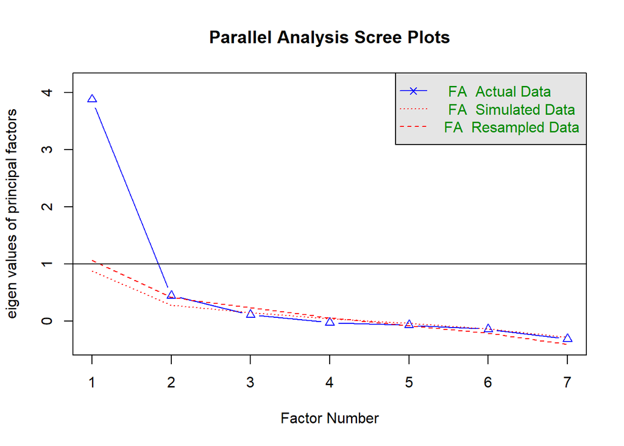

```
## Parallel analysis suggests that the number of factors =  2  and the number of components =  NA
```

```r
fa.parallel(test_2, n.obs=NULL, fm="uls", fa="fa", nfactors=1, main="Parallel Analysis Scree Plots", n.iter=20, error.bars=FALSE, se.bars=FALSE, SMC=FALSE, ylabel=NULL, show.legend=TRUE, sim=TRUE, quant=.95, cor="poly", use="pairwise", plot=TRUE, correct=.5) # suggest 2 factors
```

```r
fa(test_2, nfactors = 2, n.obs = NA, rotate = "quartimin", fm = "uls", cor = "poly") # factor 1: with 5 items; factor 2: 2 items
```

```
## Factor Analysis using method =  uls
## Call: fa(r = test_2, nfactors = 2, n.obs = NA, rotate = "quartimin",
##     fm = "uls", cor = "poly")
## Standardized loadings (pattern matrix) based upon correlation matrix
##      ULS1  ULS2   h2     u2 com
## q128 0.78  0.27 0.92 0.0796 1.2
## q129 0.55  0.44 0.77 0.2324 1.9
## q130 0.07  0.96 1.00 0.0027 1.0
## q131 0.48 -0.20 0.16 0.8380 1.3
## q132 0.73 -0.23 0.40 0.5974 1.2
## q134 0.78 -0.22 0.47 0.5340 1.2
## q135 0.86  0.20 0.96 0.0402 1.1
##
##                       ULS1 ULS2
## SS loadings           3.17 1.51
## Proportion Var        0.45 0.22
## Cumulative Var        0.45 0.67
## Proportion Explained  0.68 0.32
## Cumulative Proportion 0.68 1.00
##
##  With factor correlations of
##      ULS1 ULS2
## ULS1 1.00 0.55
## ULS2 0.55 1.00
##
## Mean item complexity =  1.3
## Test of the hypothesis that 2 factors are sufficient.
##
## The degrees of freedom for the null model are  21  and the objective function was  5.94 with Chi Square of  539.61
## The degrees of freedom for the model are 8  and the objective function was  0.82
##
## The root mean square of the residuals (RMSR) is  0.03
## The df corrected root mean square of the residuals is  0.06
##
## The harmonic number of observations is  94 with the empirical chi square  4.82  with prob <  0.78
## The total number of observations was  95  with Likelihood Chi Square =  73.42  with prob <  1e-12
##
## Tucker Lewis Index of factoring reliability =  0.664
## RMSEA index =  0.293  and the 90 % confidence intervals are  0.235 0.359
## BIC =  36.99
## Fit based upon off diagonal values = 1
```

- factor 1: positive parenting
128. En casa, estamos de acuerdo con reglas claras sobre lo que mi joven puede y no puede hacer.
129. Cuando mi joven hace algo mal, le grito o le insulto
130. Puedo controlar mi enojo y mantenerme calmado/a cuando disciplino o discuto con mi joven cuando él / ella hace algo mal
131. Cuando mi joven está aprendiendo un nuevo comportamiento (…), reconozco su progreso con, por ejemplo, un abrazo, una sonrisa o un pequeño regalo
132. Cuando mi joven se enfrenta a un gran desafío o establece una meta, le ayudo a centrarse en los pequeños pasos para lograr esa meta.

```r
posi_parent <- parent_w1 %>%
  select(q128, q131, q132, q134, q135)

alpha(posi_parent) # 0.72 (0.76 if removing q131)
```

```
##
## Reliability analysis
## Call: alpha(x = posi_parent)
##
##   raw_alpha std.alpha G6(smc) average_r S/N   ase mean   sd median_r
##       0.72      0.74    0.72      0.37 2.9 0.047  3.2 0.36     0.34
##
##     95% confidence boundaries
##          lower alpha upper
## Feldt     0.62  0.72  0.80
## Duhachek  0.62  0.72  0.81
##
##  Reliability if an item is dropped:
##      raw_alpha std.alpha G6(smc) average_r S/N alpha se var.r med.r
## q128      0.62      0.65    0.62      0.32 1.9    0.065 0.020  0.27
## q131      0.76      0.77    0.73      0.46 3.4    0.040 0.014  0.45
## q132      0.68      0.72    0.69      0.39 2.5    0.055 0.036  0.37
## q134      0.65      0.68    0.65      0.35 2.1    0.060 0.026  0.31
## q135      0.63      0.64    0.59      0.31 1.8    0.063 0.010  0.28
##
##  Item statistics
##       n raw.r std.r r.cor r.drop mean   sd
## q128 94  0.76  0.78  0.73   0.59  3.3 0.52
## q131 95  0.60  0.54  0.33   0.29  2.9 0.65
## q132 94  0.66  0.66  0.51   0.44  3.1 0.54
## q134 95  0.71  0.73  0.64   0.53  3.3 0.49
## q135 95  0.76  0.80  0.77   0.63  3.2 0.42
##
## Non missing response frequency for each item
##         2    3    4 miss
## q128 0.02 0.63 0.35 0.01
## q131 0.26 0.57 0.17 0.00
## q132 0.12 0.71 0.17 0.01
## q134 0.02 0.68 0.29 0.00
## q135 0.00 0.77 0.23 0.00
```

- factor 2: consistency (only 2 items, though)
129. Mi joven sabe cómo voy a responder cuando hace algo malo cosas que no me gustan o lo que está en contra las reglas de la casa)
130. Cada vez que mi joven hace algo mal, yo le respondo con una consecuencia específica (por ejemplo, una disciplina específica, quitándole privilegios, etc.)

```r
# consistency <- parent_w1 %>%
#   select(q129, q130)
#
# alpha(consistency) # 0.77
```

```r
# test_3<- parent_w1 %>%
#   select(q128, q129, q130, q132, q134, q135) # NO EFA here, just face value.
#
# alpha(test_3) # 0.83 (0.83 if all caregivers included)
#
#
# discip_pos <- parent_w1 %>%
#   select(q128, q129, q130, q132) # NO EFA here, just face value.
#
# alpha(discip_pos) # 0.77
#
# discip_neg <- parent_w1 %>%
#   select(q131, q133, q136) # NO EFA here, just face value.
#
# alpha(discip_neg) # 0.50
```

# From my diss:

- Structure at home Structure at Home. Eight items reflecting parent’s endorsement of their employment of school-like functions in the home environment conformed this Juntos-developed measure. Sample items included statements such as “I have taken measures to support my youth to meet deadlines,” and “I have taken measures to support my youth to find ways to be involved in volunteer activities in the community.” Two items slightly overlap with the homework involvement construct, “I have taken measures to support my youth in developing a plan to study and complete homework,” and “I have taken measures to support my youth in developing a schedule to complete homework and school projects,” but given their focus on organization and structure, they were kept here. Response options used a Likert scale that ranged from (1) “strongly disagree” to (4) “strongly agree.” … This scale continued to index parents’ practices to create a continuity between the school and home environment in terms of structure and planning to support youth academic behaviors (α = .82).”

23 … desarrollar un plan para estudiar y hacer la tarea. 24 … encontrar formas de involucrarse en las actividades escolares. 25 … encontrar maneras de involucrarse en actividades de voluntario/a en la comunidad. 26 … hacer metas para el año escolar. 27 … cumplir fechas de limite. 28 … participar en papeles de liderazgo en la escuela o comunidad. 29 … enfocarse en hacer lo mejor posible. 30 … desarrollar un horario para completar la tarea y los proyectos escolares a tiempo.

```r
struct <- parent_w1 %>%
  select(q23:q30)

alpha(struct) # 0.82 (0.82 if all caregivers included)
```

```
##
## Reliability analysis
## Call: alpha(x = struct)
##
##   raw_alpha std.alpha G6(smc) average_r S/N   ase mean   sd median_r
##       0.82      0.82    0.84      0.37 4.6 0.028  2.9 0.43     0.37
##
##     95% confidence boundaries
##          lower alpha upper
## Feldt     0.76  0.82  0.87
## Duhachek  0.77  0.82  0.88
##
##  Reliability if an item is dropped:
##     raw_alpha std.alpha G6(smc) average_r S/N alpha se var.r med.r
## q23      0.80      0.80    0.81      0.36 4.0    0.032 0.018  0.35
## q24      0.78      0.79    0.80      0.34 3.7    0.034 0.018  0.35
## q25      0.82      0.82    0.83      0.40 4.6    0.028 0.017  0.40
## q26      0.80      0.80    0.82      0.37 4.0    0.031 0.022  0.35
## q27      0.79      0.79    0.81      0.35 3.7    0.034 0.020  0.34
## q28      0.79      0.80    0.81      0.36 3.9    0.032 0.017  0.35
## q29      0.80      0.80    0.81      0.36 3.9    0.031 0.021  0.35
## q30      0.83      0.83    0.84      0.41 4.8    0.028 0.013  0.40
##
##  Item statistics
##      n raw.r std.r r.cor r.drop mean   sd
## q23 95  0.69  0.69  0.65   0.57  2.9 0.63
## q24 95  0.76  0.76  0.74   0.66  2.9 0.65
## q25 95  0.57  0.55  0.46   0.41  2.6 0.72
## q26 94  0.66  0.68  0.61   0.55  3.0 0.60
## q27 94  0.75  0.75  0.72   0.65  3.0 0.66
## q28 94  0.72  0.70  0.66   0.59  2.6 0.71
## q29 95  0.68  0.69  0.64   0.57  3.3 0.61
## q30 95  0.50  0.52  0.42   0.35  3.2 0.60
##
## Non missing response frequency for each item
##        1    2    3    4 miss
## q23 0.03 0.14 0.69 0.14 0.00
## q24 0.03 0.18 0.66 0.13 0.00
## q25 0.05 0.37 0.49 0.08 0.00
## q26 0.01 0.13 0.67 0.19 0.01
## q27 0.01 0.19 0.61 0.19 0.01
## q28 0.05 0.39 0.48 0.07 0.01
## q29 0.01 0.05 0.59 0.35 0.00
## q30 0.01 0.07 0.64 0.27 0.00
```

# From my diss:

- School-based inv School-Based Involvement. Ten items reflecting the level of parent’s endorsement of their involvement in some school-based activities and their efforts in familiarizing themselves with the U.S. school system constituted this Juntos-developed measure. Sample items included, “In general, I make an effort to become involved in school activities, in [my youth’s] classroom, and/or other ways (e.g., parent committees, volunteering, etc.),” and “In general, I make an effort to understand the school’s rules and policies.” Response options used a Likert scale that ranged from (1) “strongly disagree” to (4) “strongly agree.”

“Analyses of items in factor one (n = 4) appeared to index a basic level of parent school-based involvement, mostly composed by practices in which the parent gets acquainted with the school personnel and policies (α = .85). Items in factor two (n = 5) indexed parents’ school-based practices that required a higher investment of time and efforts like volunteering at school, establishing connections with other school parents, and understanding the pathways to prepare for college (α = .82).”

31. … conocer el personal y la administración de la escuela
32. … conocer al menos uno de los maestros de mi joven
33. … entender las reglas y pólizas de la escuela
34. … informarme sobre mis derechos como padre
35. … aprender sobre el sistema educativo en este estado
36. … entender la diferencia entre obtener un GED, graduarse con un diploma estándar de la escuela secundaria, o con un diploma de una secundaria internacional o con un diploma de Bachillerato Internacional.
37. … involucrarse en las actividades escolares, en el salón de clase, y/u otras maneras (por ejemplo, organizaciones de padres, trabajo voluntario, etc.)
38. … tener conversaciones con los otros padres para obtener información o aprender acerca de los recursos en la escuela.
39. …contactar los otros padres para obtener apoyo.
40. …entender la trayectoria hacia la preparación a la universidad y para una carrera
41. … asistir a la conferencia de padres y maestros cuando esté disponible.

```r
sbi_test <- parent_w1 %>%
  select(q31, q32, q33, q34, q35, q36, q37, q38, q39, q40) # 41 removed .30 loading

fa(sbi_test, n.obs = NA, rotate = "none", fm = "uls", cor = "poly") # looks good
```

```
## Factor Analysis using method =  uls
## Call: fa(r = sbi_test, n.obs = NA, rotate = "none", fm = "uls", cor = "poly")
## Standardized loadings (pattern matrix) based upon correlation matrix
##     ULS1   h2   u2 com
## q31 0.62 0.39 0.61   1
## q32 0.72 0.51 0.49   1
## q33 0.80 0.64 0.36   1
## q34 0.84 0.71 0.29   1
## q35 0.80 0.65 0.35   1
## q36 0.68 0.47 0.53   1
## q37 0.59 0.34 0.66   1
## q38 0.65 0.42 0.58   1
## q39 0.55 0.30 0.70   1
## q40 0.74 0.55 0.45   1
##
##                ULS1
## SS loadings    4.98
## Proportion Var 0.50
##
## Mean item complexity =  1
## Test of the hypothesis that 1 factor is sufficient.
##
## The degrees of freedom for the null model are  45  and the objective function was  8.67 with Chi Square of  778.52
## The degrees of freedom for the model are 35  and the objective function was  3.87
##
## The root mean square of the residuals (RMSR) is  0.16
## The df corrected root mean square of the residuals is  0.18
##
## The harmonic number of observations is  94 with the empirical chi square  206.74  with prob <  3.1e-26
## The total number of observations was  95  with Likelihood Chi Square =  345.13  with prob <  1.2e-52
##
## Tucker Lewis Index of factoring reliability =  0.452
## RMSEA index =  0.305  and the 90 % confidence intervals are  0.278 0.337
## BIC =  185.75
## Fit based upon off diagonal values = 0.91
## Measures of factor score adequacy
##                                                   ULS1
## Correlation of (regression) scores with factors   0.96
## Multiple R square of scores with factors          0.92
## Minimum correlation of possible factor scores     0.84
```

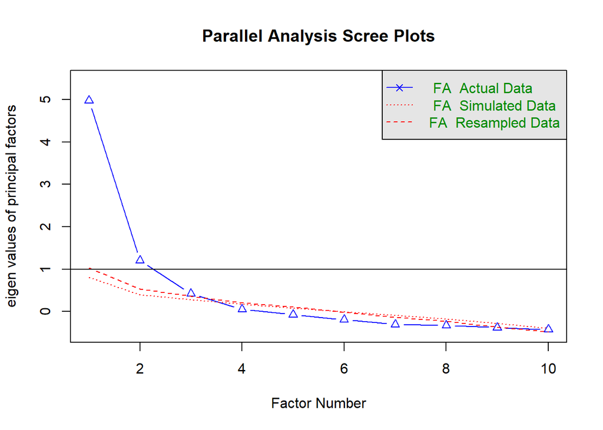

```
## Parallel analysis suggests that the number of factors =  3  and the number of components =  NA
```

```r
fa.parallel(sbi_test, n.obs=NULL, fm="uls", fa="fa", nfactors=1, main="Parallel Analysis Scree Plots", n.iter=20, error.bars=FALSE, se.bars=FALSE, SMC=FALSE, ylabel=NULL, show.legend=TRUE, sim=TRUE, quant=.95, cor="poly", use="pairwise", plot=TRUE, correct=.5) # suggest 3 factors
```

```r
fa(sbi_test, nfactors = 3, n.obs = NA, rotate = "quartimin", fm = "uls", cor = "poly")
```

```
## Factor Analysis using method =  uls
## Call: fa(r = sbi_test, nfactors = 3, n.obs = NA, rotate = "quartimin",
##     fm = "uls", cor = "poly")
## Standardized loadings (pattern matrix) based upon correlation matrix
##      ULS1  ULS2  ULS3   h2   u2 com
## q31  0.61  0.34 -0.49 0.79 0.21 2.5
## q32  0.96 -0.13 -0.06 0.83 0.17 1.0
## q33  0.96 -0.04 -0.03 0.89 0.11 1.0
## q34  0.84  0.05  0.16 0.79 0.21 1.1
## q35  0.66  0.15  0.29 0.67 0.33 1.5
## q36  0.33  0.30  0.55 0.69 0.31 2.3
## q37 -0.03  0.69  0.30 0.63 0.37 1.4
## q38 -0.03  0.96 -0.10 0.86 0.14 1.0
## q39 -0.05  0.78  0.00 0.58 0.42 1.0
## q40  0.30  0.43  0.43 0.69 0.31 2.8
##
##                       ULS1 ULS2 ULS3
## SS loadings           3.73 2.66 1.03
## Proportion Var        0.37 0.27 0.10
## Cumulative Var        0.37 0.64 0.74
## Proportion Explained  0.50 0.36 0.14
## Cumulative Proportion 0.50 0.86 1.00
##
##  With factor correlations of
##      ULS1 ULS2 ULS3
## ULS1 1.00 0.46 0.09
## ULS2 0.46 1.00 0.20
## ULS3 0.09 0.20 1.00
##
## Mean item complexity =  1.6
## Test of the hypothesis that 3 factors are sufficient.
##
## The degrees of freedom for the null model are  45  and the objective function was  8.67 with Chi Square of  778.52
## The degrees of freedom for the model are 18  and the objective function was  1.06
##
## The root mean square of the residuals (RMSR) is  0.03
## The df corrected root mean square of the residuals is  0.05
##
## The harmonic number of observations is  94 with the empirical chi square  9.62  with prob <  0.94
## The total number of observations was  95  with Likelihood Chi Square =  92.9  with prob <  4.3e-12
##
## Tucker Lewis Index of factoring reliability =  0.739
## RMSEA index =  0.209  and the 90 % confidence intervals are  0.169 0.254
## BIC =  10.93
## Fit based upon off diagonal values = 1
## Measures of factor score adequacy
##                                                   ULS1 ULS2 ULS3
## Correlation of (regression) scores with factors   0.98 0.96 0.88
## Multiple R square of scores with factors          0.96 0.92 0.78
## Minimum correlation of possible factor scores     0.91 0.84 0.56
```

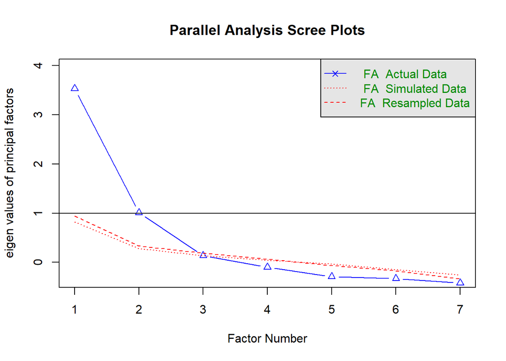

```
## Parallel analysis suggests that the number of factors =  2  and the number of components =  NA
```

```r
sbi_test_2 <- parent_w1 %>%
  select(q32, q33, q34, q35, q37, q38, q39)

fa.parallel(sbi_test_2, n.obs=NULL, fm="uls", fa="fa", nfactors=1, main="Parallel Analysis Scree Plots", n.iter=20, error.bars=FALSE, se.bars=FALSE, SMC=FALSE, ylabel=NULL, show.legend=TRUE, sim=TRUE, quant=.95, cor="poly", use="pairwise", plot=TRUE, correct=.5) # suggest 2 factors
```

```r
fa(sbi_test_2, nfactors = 2, n.obs = NA, rotate = "quartimin", fm = "uls", cor = "poly")
```

```
## Factor Analysis using method =  uls
## Call: fa(r = sbi_test_2, nfactors = 2, n.obs = NA, rotate = "quartimin",
##     fm = "uls", cor = "poly")
## Standardized loadings (pattern matrix) based upon correlation matrix
##      ULS1  ULS2   h2   u2 com
## q32  0.95 -0.11 0.82 0.18 1.0
## q33  0.96 -0.02 0.90 0.10 1.0
## q34  0.82  0.13 0.78 0.22 1.1
## q35  0.64  0.24 0.59 0.41 1.3
## q37  0.01  0.77 0.60 0.40 1.0
## q38  0.03  0.84 0.73 0.27 1.0
## q39 -0.03  0.79 0.60 0.40 1.0
##
##                       ULS1 ULS2
## SS loadings           2.95 2.06
## Proportion Var        0.42 0.29
## Cumulative Var        0.42 0.72
## Proportion Explained  0.59 0.41
## Cumulative Proportion 0.59 1.00
##
##  With factor correlations of
##      ULS1 ULS2
## ULS1  1.0  0.4
## ULS2  0.4  1.0
##
## Mean item complexity =  1.1
## Test of the hypothesis that 2 factors are sufficient.
##
## The degrees of freedom for the null model are  21  and the objective function was  5.7 with Chi Square of  517.48
## The degrees of freedom for the model are 8  and the objective function was  0.84
##
## The root mean square of the residuals (RMSR) is  0.05
## The df corrected root mean square of the residuals is  0.07
##
## The harmonic number of observations is  94 with the empirical chi square  8.37  with prob <  0.4
## The total number of observations was  95  with Likelihood Chi Square =  75.03  with prob <  4.9e-13
##
## Tucker Lewis Index of factoring reliability =  0.64
## RMSEA index =  0.297  and the 90 % confidence intervals are  0.239 0.362
## BIC =  38.6
## Fit based upon off diagonal values = 0.99
## Measures of factor score adequacy
##                                                   ULS1 ULS2
## Correlation of (regression) scores with factors   0.98 0.93
## Multiple R square of scores with factors          0.95 0.86
## Minimum correlation of possible factor scores     0.91 0.72
```

32 … conocer al menos uno de los maestros de mi joven 33 … entender las reglas y pólizas de la escuela 34 … informarme sobre mis derechos como padre 35 … aprender sobre el sistema educativo en este estado

```r
sbi_1 <- parent_w1 %>%
  select(q32, q33, q34, q35)

alpha(sbi_1) # 0.84
```

```
##
## Reliability analysis
## Call: alpha(x = sbi_1)
##
##   raw_alpha std.alpha G6(smc) average_r S/N   ase mean   sd median_r
##       0.84      0.84    0.84      0.58 5.5 0.026    3 0.52     0.59
##
##     95% confidence boundaries
##          lower alpha upper
## Feldt     0.79  0.84  0.89
## Duhachek  0.79  0.84  0.90
##
##  Reliability if an item is dropped:
##     raw_alpha std.alpha G6(smc) average_r S/N alpha se  var.r med.r
## q32      0.80      0.80    0.74      0.58 4.1    0.035 0.0058  0.60
## q33      0.77      0.77    0.72      0.53 3.4    0.039 0.0172  0.57
## q34      0.79      0.79    0.76      0.55 3.7    0.039 0.0404  0.49
## q35      0.84      0.85    0.80      0.65 5.5    0.029 0.0122  0.60
##
##  Item statistics
##      n raw.r std.r r.cor r.drop mean   sd
## q32 95  0.82  0.83  0.78   0.68  3.0 0.58
## q33 95  0.86  0.87  0.83   0.74  3.0 0.63
## q34 95  0.86  0.85  0.78   0.72  2.9 0.68
## q35 95  0.76  0.76  0.64   0.59  2.9 0.62
##
## Non missing response frequency for each item
##        1    2    3    4 miss
## q32 0.02 0.09 0.73 0.16    0
## q33 0.02 0.12 0.66 0.20    0
## q34 0.03 0.18 0.63 0.16    0
## q35 0.03 0.14 0.71 0.13    0
```

37 … involucrarse en las actividades escolares, en el salón de clase, y/u otras maneras (por ejemplo, organizaciones de padres, trabajo voluntario, etc.) 38 … tener conversaciones con los otros padres para obtener información o aprender acerca de los recursos en la escuela. 39 …contactar los otros padres para obtener apoyo.

```r
sbi_2 <- parent_w1 %>% # taps on connecting with parents
  select(q37, q38, q39)

alpha(sbi_2) # 0.79
```

```
##
## Reliability analysis
## Call: alpha(x = sbi_2)
##
##   raw_alpha std.alpha G6(smc) average_r S/N   ase mean   sd median_r
##       0.79      0.79    0.73      0.56 3.8 0.037  2.5 0.57     0.55
##
##     95% confidence boundaries
##          lower alpha upper
## Feldt     0.71  0.79  0.86
## Duhachek  0.72  0.79  0.86
##
##  Reliability if an item is dropped:
##     raw_alpha std.alpha G6(smc) average_r S/N alpha se var.r med.r
## q37      0.78      0.78    0.64      0.64 3.6    0.045    NA  0.64
## q38      0.65      0.65    0.48      0.48 1.8    0.073    NA  0.48
## q39      0.71      0.71    0.55      0.55 2.5    0.059    NA  0.55
##
##  Item statistics
##      n raw.r std.r r.cor r.drop mean   sd
## q37 94  0.80  0.81  0.63   0.57  2.6 0.66
## q38 94  0.88  0.87  0.79   0.70  2.5 0.71
## q39 95  0.84  0.84  0.72   0.64  2.3 0.68
##
## Non missing response frequency for each item
##        1    2    3    4 miss
## q37 0.01 0.48 0.43 0.09 0.01
## q38 0.07 0.45 0.43 0.05 0.01
## q39 0.08 0.54 0.35 0.03 0.00
```

- Parent-child convos Parent-Child Conversations About School. A total of 14 items reflecting the frequency in which parents engaged in conversations with their youth about school (e.g., events happening at school, youth’s behavior, academic engagement, progress at school, challenging events like bullying or discrimination, youth’s school friends etc.) constituted this Juntos-developed measure. Sample items included “I have had conversations with my youth about things they learn in class,” and “I have had conversations with my youth about things that happen at school.” A subset of three items tap into conversations about college and career planning. Response options used a Likert scale that ranged from (1) “never” to (4) “often.”

Items in factor one (n = 4) appeared to index conversations around youth’s school climate and youth’s behavior in school (α = .85); items in factor two (n = 4) indexed conversations around future career planning and activities conducive to attending college (α = .78). Finally, items in factors three (n = 4) appeared to reflect conversations around the youth’s school social involvement; specifically, the youth’s relationship with school friends, teachers, and their involvement in school activities and upcoming school events (α = .81).

68. … sus amistades en la escuela.
69. … su participación en actividades escolares.
70. … eventos que van a pasar en la escuela.
71. … sus profesores.
72. … las cosas que aprende en clase.
73. … cómo contribuye al salón de clase.
74. … cómo va en sus clases.
75. … sus futuros objetivos de carrera y educación (incluso los objetivos a corto plazo).
76. … desafíos que surgen en la escuela (como intimidación, agresión, acoso, racismo, peleas, etc.)
77. … sus actitudes sobre la escuela
78. … su comportamiento en la escuela
79. … las cosas que suceden en la escuela (el ambiente escolar en general)
80. … la importancia de prepararse para futuras trayectorias educativas o de carrera, como la planificación universitaria y/o pensando acerca de la escuela técnica o comercial
81. … su involucro en actividades extracurriculares en la escuela y en la comunidad como en papeles de liderazgo, haciendo trabajo voluntario en la comunidad, deportes, etc.

```r
convos_test <- parent_w1 %>%
  select(q68, q69, q70, q71, q72, q73, q74, q75, q76, q77, q78, q79, q80, q81)

fa(convos_test, n.obs = NA, rotate = "none", fm = "uls", cor = "poly") # looks good
```

```
## Factor Analysis using method =  uls
## Call: fa(r = convos_test, n.obs = NA, rotate = "none", fm = "uls",
##     cor = "poly")
## Standardized loadings (pattern matrix) based upon correlation matrix
##     ULS1   h2   u2 com
## q68 0.68 0.46 0.54   1
## q69 0.76 0.58 0.42   1
## q70 0.67 0.44 0.56   1
## q71 0.73 0.53 0.47   1
## q72 0.71 0.50 0.50   1
## q73 0.62 0.38 0.62   1
## q74 0.88 0.77 0.23   1
## q75 0.77 0.60 0.40   1
## q76 0.71 0.51 0.49   1
## q77 0.84 0.70 0.30   1
## q78 0.79 0.62 0.38   1
## q79 0.78 0.61 0.39   1
## q80 0.65 0.42 0.58   1
## q81 0.50 0.25 0.75   1
##
##                ULS1
## SS loadings    7.38
## Proportion Var 0.53
##
## Mean item complexity =  1
## Test of the hypothesis that 1 factor is sufficient.
##
## The degrees of freedom for the null model are  91  and the objective function was  12.91 with Chi Square of  1142.97
## The degrees of freedom for the model are 77  and the objective function was  4.79
##
## The root mean square of the residuals (RMSR) is  0.11
## The df corrected root mean square of the residuals is  0.12
##
## The harmonic number of observations is  95 with the empirical chi square  193.25  with prob <  5.7e-12
## The total number of observations was  95  with Likelihood Chi Square =  420.35  with prob <  9.5e-49
##
## Tucker Lewis Index of factoring reliability =  0.611
## RMSEA index =  0.216  and the 90 % confidence intervals are  0.198 0.238
## BIC =  69.7
## Fit based upon off diagonal values = 0.96
## Measures of factor score adequacy
##                                                   ULS1
## Correlation of (regression) scores with factors   0.97
## Multiple R square of scores with factors          0.95
## Minimum correlation of possible factor scores     0.90
```

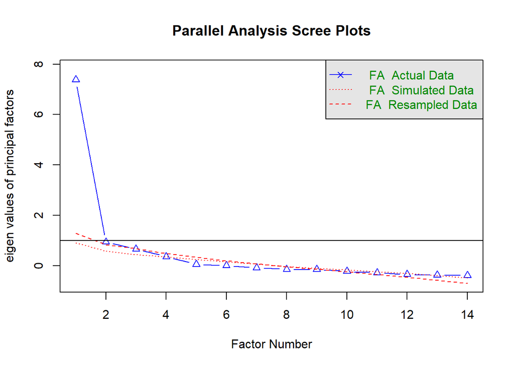

```
## Parallel analysis suggests that the number of factors =  3  and the number of components =  NA
```

```r
fa.parallel(convos_test, n.obs=NULL, fm="uls", fa="fa", nfactors=1, main="Parallel Analysis Scree Plots", n.iter=20, error.bars=FALSE, se.bars=FALSE, SMC=FALSE, ylabel=NULL, show.legend=TRUE, sim=TRUE, quant=.95, cor="poly", use="pairwise", plot=TRUE, correct=.5) # suggest 3 factors
```

```r
fa(convos_test, nfactors = 3, n.obs = NA, rotate = "quartimin", fm = "uls", cor = "poly")
```

```
## Factor Analysis using method =  uls
## Call: fa(r = convos_test, nfactors = 3, n.obs = NA, rotate = "quartimin",
##     fm = "uls", cor = "poly")
## Standardized loadings (pattern matrix) based upon correlation matrix
##      ULS1  ULS3  ULS2   h2   u2 com
## q68  0.23  0.52  0.04 0.50 0.50 1.4
## q69  0.01  0.83  0.06 0.77 0.23 1.0
## q70  0.03  0.84 -0.09 0.66 0.34 1.0
## q71  0.04  0.77  0.05 0.68 0.32 1.0
## q72  0.10  0.36  0.41 0.54 0.46 2.1
## q73  0.09  0.31  0.36 0.41 0.59 2.1
## q74  0.49  0.14  0.41 0.78 0.22 2.1
## q75  0.24  0.02  0.73 0.79 0.21 1.2
## q76  0.75 -0.01  0.09 0.62 0.38 1.0
## q77  0.81  0.17 -0.02 0.85 0.15 1.1
## q78  0.96 -0.05  0.01 0.87 0.13 1.0
## q79  0.79  0.12 -0.01 0.75 0.25 1.0
## q80  0.14 -0.09  0.82 0.72 0.28 1.1
## q81 -0.26  0.16  0.79 0.60 0.40 1.3
##
##                       ULS1 ULS3 ULS2
## SS loadings           3.70 3.07 2.75
## Proportion Var        0.26 0.22 0.20
## Cumulative Var        0.26 0.48 0.68
## Proportion Explained  0.39 0.32 0.29
## Cumulative Proportion 0.39 0.71 1.00
##
##  With factor correlations of
##      ULS1 ULS3 ULS2
## ULS1 1.00 0.64 0.48
## ULS3 0.64 1.00 0.52
## ULS2 0.48 0.52 1.00
##
## Mean item complexity =  1.3
## Test of the hypothesis that 3 factors are sufficient.
##
## The degrees of freedom for the null model are  91  and the objective function was  12.91 with Chi Square of  1142.97
## The degrees of freedom for the model are 52  and the objective function was  2.28
##
## The root mean square of the residuals (RMSR) is  0.05
## The df corrected root mean square of the residuals is  0.06
##
## The harmonic number of observations is  95 with the empirical chi square  38.79  with prob <  0.91
## The total number of observations was  95  with Likelihood Chi Square =  197.55  with prob <  8e-19
##
## Tucker Lewis Index of factoring reliability =  0.752
## RMSEA index =  0.171  and the 90 % confidence intervals are  0.147 0.198
## BIC =  -39.25
## Fit based upon off diagonal values = 0.99
## Measures of factor score adequacy
##                                                   ULS1 ULS3 ULS2
## Correlation of (regression) scores with factors   0.98 0.95 0.94
## Multiple R square of scores with factors          0.95 0.90 0.89
## Minimum correlation of possible factor scores     0.90 0.81 0.78
```

```r
convos_test2 <- parent_w1 %>%
  select(q68, q69, q70, q71, q75, q76, q77, q78, q79, q80, q81) # removed q72, q73, q74 bec. loaded in >1 factors

fa(convos_test2, n.obs = NA, rotate = "none", fm = "uls", cor = "poly") # looks good
```

```
## Factor Analysis using method =  uls
## Call: fa(r = convos_test2, n.obs = NA, rotate = "none", fm = "uls",
##     cor = "poly")
## Standardized loadings (pattern matrix) based upon correlation matrix
##     ULS1   h2   u2 com
## q68 0.69 0.47 0.53   1
## q69 0.78 0.60 0.40   1
## q70 0.67 0.45 0.55   1
## q71 0.73 0.53 0.47   1
## q75 0.73 0.54 0.46   1
## q76 0.73 0.54 0.46   1
## q77 0.86 0.74 0.26   1
## q78 0.81 0.65 0.35   1
## q79 0.80 0.64 0.36   1
## q80 0.61 0.37 0.63   1
## q81 0.45 0.20 0.80   1
##
##                ULS1
## SS loadings    5.74
## Proportion Var 0.52
##
## Mean item complexity =  1
## Test of the hypothesis that 1 factor is sufficient.
##
## The degrees of freedom for the null model are  55  and the objective function was  9.44 with Chi Square of  844.58
## The degrees of freedom for the model are 44  and the objective function was  3.51
##
## The root mean square of the residuals (RMSR) is  0.12
## The df corrected root mean square of the residuals is  0.13
##
## The harmonic number of observations is  95 with the empirical chi square  147.51  with prob <  4.2e-13
## The total number of observations was  95  with Likelihood Chi Square =  312.1  with prob <  4.4e-42
##
## Tucker Lewis Index of factoring reliability =  0.572
## RMSEA index =  0.253  and the 90 % confidence intervals are  0.228 0.282
## BIC =  111.73
## Fit based upon off diagonal values = 0.95
## Measures of factor score adequacy
##                                                   ULS1
## Correlation of (regression) scores with factors   0.97
## Multiple R square of scores with factors          0.93
## Minimum correlation of possible factor scores     0.87
```

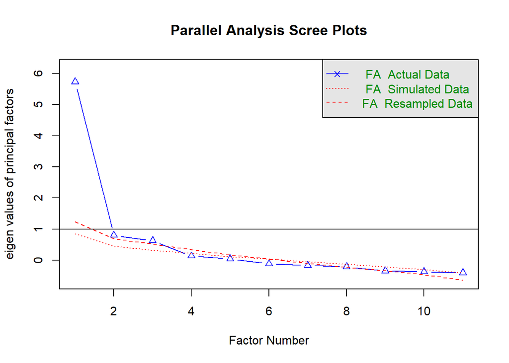

```
## Parallel analysis suggests that the number of factors =  3  and the number of components =  NA
```

```r
fa.parallel(convos_test2, n.obs=NULL, fm="uls", fa="fa", nfactors=1, main="Parallel Analysis Scree Plots", n.iter=20, error.bars=FALSE, se.bars=FALSE, SMC=FALSE, ylabel=NULL, show.legend=TRUE, sim=TRUE, quant=.95, cor="poly", use="pairwise", plot=TRUE, correct=.5) # suggest 3 factors
```

```r
fa(convos_test2, nfactors = 3, n.obs = NA, rotate = "quartimin", fm = "uls", cor = "poly")
```

```
## Factor Analysis using method =  uls
## Call: fa(r = convos_test2, nfactors = 3, n.obs = NA, rotate = "quartimin",
##     fm = "uls", cor = "poly")
## Standardized loadings (pattern matrix) based upon correlation matrix
##      ULS1  ULS3  ULS2   h2    u2 com
## q68  0.17  0.58  0.04 0.52 0.481 1.2
## q69 -0.03  0.89  0.07 0.83 0.174 1.0
## q70  0.06  0.80 -0.09 0.63 0.367 1.0
## q71  0.10  0.69  0.06 0.63 0.374 1.1
## q75  0.18  0.10  0.71 0.75 0.247 1.2
## q76  0.71  0.03  0.11 0.62 0.385 1.1
## q77  0.79  0.19  0.00 0.84 0.158 1.1
## q78  0.99 -0.07  0.02 0.91 0.089 1.0
## q79  0.78  0.13  0.01 0.75 0.250 1.1
## q80  0.12 -0.09  0.87 0.79 0.214 1.1
## q81 -0.23  0.17  0.74 0.55 0.448 1.3
##
##                       ULS1 ULS3 ULS2
## SS loadings           3.15 2.66 2.01
## Proportion Var        0.29 0.24 0.18
## Cumulative Var        0.29 0.53 0.71
## Proportion Explained  0.40 0.34 0.26
## Cumulative Proportion 0.40 0.74 1.00
##
##  With factor correlations of
##      ULS1 ULS3 ULS2
## ULS1 1.00 0.62 0.47
## ULS3 0.62 1.00 0.50
## ULS2 0.47 0.50 1.00
##
## Mean item complexity =  1.1
## Test of the hypothesis that 3 factors are sufficient.
##
## The degrees of freedom for the null model are  55  and the objective function was  9.44 with Chi Square of  844.58
## The degrees of freedom for the model are 25  and the objective function was  1.28
##
## The root mean square of the residuals (RMSR) is  0.04
## The df corrected root mean square of the residuals is  0.06
##
## The harmonic number of observations is  95 with the empirical chi square  17.9  with prob <  0.85
## The total number of observations was  95  with Likelihood Chi Square =  111.63  with prob <  6.4e-13
##
## Tucker Lewis Index of factoring reliability =  0.753
## RMSEA index =  0.191  and the 90 % confidence intervals are  0.157 0.229
## BIC =  -2.21
## Fit based upon off diagonal values = 0.99
## Measures of factor score adequacy
##                                                   ULS1 ULS3 ULS2
## Correlation of (regression) scores with factors   0.98 0.96 0.94
## Multiple R square of scores with factors          0.96 0.91 0.88
## Minimum correlation of possible factor scores     0.92 0.83 0.76
```

Factor 1 76 … desafíos que surgen en la escuela (como intimidación, agresión, acoso, racismo, peleas, etc.) 77 … sus actitudes sobre la escuela. 78 … su comportamiento en la escuela. 79 … las cosas que suceden en la escuela (el ambiente escolar en general).

if adding back q74, this factor would be somewhat a general check in. 74. … cómo va en sus clases.

```r
# clim_convo <- parent_w1 %>%
#   select(q76, q77, q78, q79)
# alpha(clim_convo) # 0.84
###
clim_convo_2 <- parent_w1 %>%
  select(q74, q76, q77, q78, q79) # adding back q74
alpha(clim_convo_2) #0.85
```

```
##
## Reliability analysis
## Call: alpha(x = clim_convo_2)
##
##   raw_alpha std.alpha G6(smc) average_r S/N   ase mean   sd median_r
##       0.85      0.86    0.84      0.55 6.1 0.023  3.6 0.55     0.51
##
##     95% confidence boundaries
##          lower alpha upper
## Feldt     0.80  0.85  0.89
## Duhachek  0.81  0.85  0.90
##
##  Reliability if an item is dropped:
##     raw_alpha std.alpha G6(smc) average_r S/N alpha se  var.r med.r
## q74      0.84      0.85    0.82      0.58 5.5    0.027 0.0118  0.56
## q76      0.86      0.86    0.83      0.61 6.2    0.022 0.0077  0.63
## q77      0.79      0.80    0.76      0.51 4.1    0.034 0.0086  0.50
## q78      0.80      0.81    0.77      0.52 4.3    0.032 0.0094  0.50
## q79      0.81      0.82    0.79      0.53 4.6    0.031 0.0151  0.50
##
##  Item statistics
##      n raw.r std.r r.cor r.drop mean   sd
## q74 95  0.73  0.75  0.66   0.61  3.8 0.55
## q76 95  0.73  0.71  0.58   0.54  3.5 0.80
## q77 95  0.87  0.86  0.84   0.76  3.5 0.81
## q78 95  0.84  0.85  0.82   0.75  3.6 0.60
## q79 95  0.82  0.82  0.77   0.71  3.5 0.70
##
## Non missing response frequency for each item
##        1    2    3    4 miss
## q74 0.02 0.00 0.17 0.81    0
## q76 0.05 0.03 0.25 0.66    0
## q77 0.06 0.01 0.28 0.64    0
## q78 0.01 0.03 0.26 0.69    0
## q79 0.02 0.05 0.33 0.60    0
```

Factor 2 75 … sus futuros objetivos de carrera y educación (incluso los objetivos a corto plazo). 80 … la importancia de prepararse para futuras trayectorias educativas o de carrera, como la planificación universitaria y / o pensando acerca de la escuela técnica o comercial, etc. 81 … su involucro en actividades extracurriculares en la escuela y en la comunidad como en papeles de liderazgo, haciendo trabajo voluntario en la comunidad, deportes, etc.

If adding back q72 & q73, factor remains the same: prep 72. … las cosas que aprende en clase 73. … cómo contribuye al salón de clase.

```r
# prep_convo <- parent_w1 %>%
#   select(q75, q80, q81)
# alpha(prep_convo) # 0.77
###
prep_convo_2 <- parent_w1 %>%
  select(q72, q73, q75, q80, q81) # adding back q72 & q73
alpha(prep_convo_2) # 0.80
```

```
##
## Reliability analysis
## Call: alpha(x = prep_convo_2)
##
##   raw_alpha std.alpha G6(smc) average_r S/N   ase mean   sd median_r
##       0.79       0.8    0.77      0.44 3.9 0.034  3.3 0.62     0.45
##
##     95% confidence boundaries
##          lower alpha upper
## Feldt     0.71  0.79  0.85
## Duhachek  0.72  0.79  0.86
##
##  Reliability if an item is dropped:
##     raw_alpha std.alpha G6(smc) average_r S/N alpha se  var.r med.r
## q72      0.77      0.78    0.74      0.47 3.5    0.039 0.0116  0.47
## q73      0.78      0.78    0.74      0.47 3.5    0.036 0.0092  0.46
## q75      0.71      0.72    0.66      0.39 2.5    0.048 0.0033  0.38
## q80      0.72      0.73    0.68      0.41 2.8    0.046 0.0053  0.42
## q81      0.76      0.77    0.73      0.45 3.3    0.038 0.0112  0.45
##
##  Item statistics
##      n raw.r std.r r.cor r.drop mean   sd
## q72 95  0.65  0.69  0.56   0.50  3.5 0.63
## q73 95  0.70  0.69  0.56   0.50  3.2 0.92
## q75 95  0.82  0.82  0.79   0.70  3.4 0.81
## q80 94  0.79  0.79  0.73   0.65  3.4 0.87
## q81 95  0.73  0.71  0.60   0.53  2.9 0.94
##
## Non missing response frequency for each item
##        1    2    3    4 miss
## q72 0.02 0.01 0.37 0.60 0.00
## q73 0.08 0.09 0.38 0.44 0.00
## q75 0.04 0.07 0.31 0.58 0.00
## q80 0.04 0.13 0.26 0.57 0.01
## q81 0.13 0.13 0.49 0.25 0.00
```

Factor 3 68 … sus amistades en la escuela. 69 … su participación en actividades escolares. 70 … eventos que van a pasar en la escuela. 71 … sus profesores.

```r
soc_convo <- parent_w1 %>%
  select(q68, q69, q70, q71)
alpha(soc_convo) # 0.79
```

```
##
## Reliability analysis
## Call: alpha(x = soc_convo)
##
##   raw_alpha std.alpha G6(smc) average_r S/N   ase mean   sd median_r
##       0.79       0.8    0.77      0.49 3.9 0.035  3.5 0.59     0.56
##
##     95% confidence boundaries
##          lower alpha upper
## Feldt     0.72  0.79  0.85
## Duhachek  0.73  0.79  0.86
##
##  Reliability if an item is dropped:
##     raw_alpha std.alpha G6(smc) average_r S/N alpha se   var.r med.r
## q68      0.80      0.80    0.73      0.58 4.1    0.035 0.00025  0.58
## q69      0.69      0.68    0.62      0.42 2.2    0.054 0.02351  0.37
## q70      0.73      0.73    0.69      0.48 2.8    0.049 0.02505  0.56
## q71      0.74      0.75    0.68      0.50 3.0    0.046 0.01234  0.56
##
##  Item statistics
##      n raw.r std.r r.cor r.drop mean   sd
## q68 95  0.69  0.71  0.56   0.48  3.6 0.69
## q69 95  0.85  0.86  0.81   0.72  3.5 0.70
## q70 95  0.82  0.80  0.70   0.63  3.4 0.82
## q71 95  0.79  0.78  0.69   0.61  3.4 0.78
##
## Non missing response frequency for each item
##        1    2    3    4 miss
## q68 0.02 0.05 0.25 0.67    0
## q69 0.01 0.08 0.34 0.57    0
## q70 0.06 0.02 0.38 0.54    0
## q71 0.04 0.05 0.37 0.54    0
```

Not included (loaded in >1 factor) 72 … las cosas que aprende en clase. 73 … cómo contribuye al salón de clase. 74 … cómo va en sus clases.(bec. it loaded in fac 2 and fac 3)

```r
# aca_convo <- parent_w1 %>%
#   select(q72, q73, q74)
# alpha(aca_convo) # 0.59 poor
```

Items about school 42. …yo entiendo cómo funciona la escuela de mi joven. 43. …puedo comunicar mis preguntas y preocupaciones con los maestros y el personal de la escuela. 44. …puedo trabajar con la escuela para encontrar una solución positiva si surge un conflicto o un problema que involucre a mi joven en la escuela. 45. …estoy ayudando a mi joven hacer bien en la escuela. 46. …estoy ayudando a mi joven prepararse para sus futuras metas de educación y carrera.

47. …parte de una comunidad con el personal de la escuela y los otros padres.
48. …tratado/a con respeto, sabiendo que mis opiniones son importantes.
49. …cómoda/o preguntando por un traductor y por materiales en español si los necesito.
50. … capaz de hablar con maestros o administradores sobre grandes preocupaciones relacionados con mi joven.
51. …dedicada/o en creando un ambiente exitoso para todos los jóvenes.
52. …feliz de que mi joven asista a esta escuela.
53. …bienvenido/a en la escuela de mi joven.
54. … esta escuela es un buen lugar para mi joven.
55. … el personal de la escuela de mi joven está haciendo cosas buenas por ella / el.
56. … la gente en la escuela de mi joven es confiable.
57. … la escuela de mi joven hace un buen trabajo preparando a los jóvenes para sus futuros.
58. … puedo encontrar ayuda para mi joven si él / ella está batallando en una clase.
59. … los maestros de mi joven se preocupan por ella/el.
60. … maestros y administradores trabajan juntos para crear un ambiente seguro y acogedor para todos.
61. … hay muchas oportunidades para la involucración de los padres.
62. … puedo tener una conversación honesta y respetuosa sobre mi joven con su maestro.
63. … puedo trabajar con un maestro para resolver cualquier problema que tenga mi joven en la escuela.
64. … que se preocupa por mi joven.
65. … quien está interesado en conocerme
66. … con quien me siento/a cómodo/a hablando sobre mi joven.
67. … de quien puedo hacer preguntas o hacer sugerencias sobre mi joven.

```r
misc_test <- parent_w1 %>%
  select(q42, q43, q44, q45, q46, q47, q48, q49, q50, q51, q52, q53, q54, q55, q56, q57, q58, q59, q60, q61, q62, q63, q64, q65, q66, q67)

fa(misc_test, n.obs = NA, rotate = "none", fm = "uls", cor = "poly") # looks good
```

```
## Factor Analysis using method =  uls
## Call: fa(r = misc_test, n.obs = NA, rotate = "none", fm = "uls", cor = "poly")
## Standardized loadings (pattern matrix) based upon correlation matrix
##     ULS1   h2   u2 com
## q42 0.76 0.58 0.42   1
## q43 0.72 0.52 0.48   1
## q44 0.75 0.56 0.44   1
## q45 0.64 0.40 0.60   1
## q46 0.59 0.35 0.65   1
## q47 0.42 0.18 0.82   1
## q48 0.64 0.41 0.59   1
## q49 0.87 0.76 0.24   1
## q50 0.80 0.64 0.36   1
## q51 0.65 0.42 0.58   1
## q52 0.89 0.80 0.20   1
## q53 0.77 0.60 0.40   1
## q54 0.76 0.58 0.42   1
## q55 0.90 0.81 0.19   1
## q56 0.90 0.81 0.19   1
## q57 0.85 0.72 0.28   1
## q58 0.80 0.64 0.36   1
## q59 0.95 0.90 0.10   1
## q60 0.82 0.68 0.32   1
## q61 0.66 0.43 0.57   1
## q62 0.85 0.72 0.28   1
## q63 0.72 0.52 0.48   1
## q64 0.75 0.56 0.44   1
## q65 0.76 0.58 0.42   1
## q66 0.73 0.53 0.47   1
## q67 0.74 0.54 0.46   1
##
##                 ULS1
## SS loadings    15.24
## Proportion Var  0.59
##
## Mean item complexity =  1
## Test of the hypothesis that 1 factor is sufficient.
##
## The degrees of freedom for the null model are  325  and the objective function was  201.21 with Chi Square of  17002.06
## The degrees of freedom for the model are 299  and the objective function was  179.71
##
## The root mean square of the residuals (RMSR) is  0.11
## The df corrected root mean square of the residuals is  0.11
##
## The harmonic number of observations is  92 with the empirical chi square  729.48  with prob <  6e-38
## The total number of observations was  95  with Likelihood Chi Square =  15065.65  with prob <  0
##
## Tucker Lewis Index of factoring reliability =  0.03
## RMSEA index =  0.721  and the 90 % confidence intervals are  0.715 0.735
## BIC =  13704.04
## Fit based upon off diagonal values = 0.97
```

[output not shown]

[output not shown]

[output not shown]

[output not shown]

[output not shown]

[output not shown]

[output not shown]

[output not shown]

[output not shown]

[output not shown]

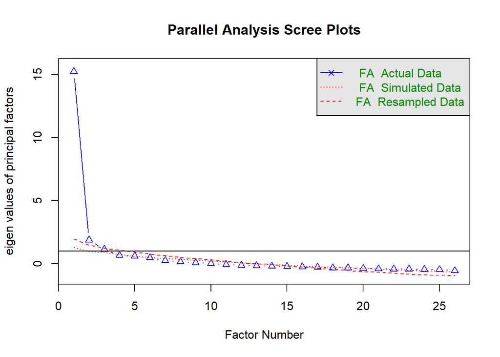

```
## Parallel analysis suggests that the number of factors =  3  and the number of components =  NA
```

```r
fa.parallel(misc_test, n.obs=NULL, fm="uls", fa="fa", nfactors=1, main="Parallel Analysis Scree Plots", n.iter=20, error.bars=FALSE, se.bars=FALSE, SMC=FALSE, ylabel=NULL, show.legend=TRUE, sim=TRUE, quant=.95, cor="poly", use="pairwise", plot=TRUE, correct=.5) # suggest 3 factors
```

```r
fa(misc_test, nfactors = 3, n.obs = NA, rotate = "quartimin", fm = "uls", cor = "poly")
```

```
## Factor Analysis using method =  uls
## Call: fa(r = misc_test, nfactors = 3, n.obs = NA, rotate = "quartimin",
##     fm = "uls", cor = "poly")
## Standardized loadings (pattern matrix) based upon correlation matrix
##      ULS2  ULS3  ULS1   h2   u2 com
## q42  0.73  0.08  0.09 0.68 0.32 1.1
## q43  0.68 -0.02  0.19 0.62 0.38 1.2
## q44  0.80  0.00  0.08 0.71 0.29 1.0
## q45  0.46  0.44 -0.16 0.51 0.49 2.2
## q46  0.54  0.34 -0.20 0.48 0.52 2.0
## q47  0.68 -0.32  0.13 0.40 0.60 1.5
## q48  0.20 -0.06  0.68 0.59 0.41 1.2
## q49  0.31  0.34  0.42 0.77 0.23 2.8
## q50  0.92  0.03 -0.01 0.87 0.13 1.0
## q51  0.86  0.18 -0.31 0.73 0.27 1.3
## q52  0.31  0.34  0.45 0.81 0.19 2.7
## q53  0.09  0.10  0.81 0.85 0.15 1.1
## q54  0.70  0.00  0.22 0.68 0.32 1.2
## q55  0.16  0.43  0.54 0.88 0.12 2.1
## q56  0.21  0.42  0.49 0.86 0.14 2.3
## q57  0.33  0.22  0.51 0.76 0.24 2.1
## q58  0.11  0.50  0.38 0.69 0.31 2.0
## q59  0.41  0.41  0.33 0.89 0.11 2.9
## q60  0.73  0.05  0.20 0.77 0.23 1.2
## q61  0.61 -0.18  0.38 0.58 0.42 1.9
## q62 -0.02  0.47  0.63 0.89 0.11 1.9
## q63 -0.01  0.69  0.21 0.65 0.35 1.2
## q64 -0.08  0.83  0.18 0.79 0.21 1.1
## q65  0.26  0.74 -0.10 0.74 0.26 1.3
## q66  0.02  0.79  0.09 0.71 0.29 1.0
## q67  0.04  0.93 -0.06 0.84 0.16 1.0
##
##                       ULS2 ULS3 ULS1
## SS loadings           7.56 6.31 4.88
## Proportion Var        0.29 0.24 0.19
## Cumulative Var        0.29 0.53 0.72
## Proportion Explained  0.40 0.34 0.26
## Cumulative Proportion 0.40 0.74 1.00
##
##  With factor correlations of
##      ULS2 ULS3 ULS1
## ULS2 1.00 0.55 0.49
## ULS3 0.55 1.00 0.48
## ULS1 0.49 0.48 1.00
##
## Mean item complexity =  1.6
## Test of the hypothesis that 3 factors are sufficient.
##
## The degrees of freedom for the null model are  325  and the objective function was  201.21 with Chi Square of  17002.06
## The degrees of freedom for the model are 250  and the objective function was  173.58
##
## The root mean square of the residuals (RMSR) is  0.06
## The df corrected root mean square of the residuals is  0.07
##
## The harmonic number of observations is  92 with the empirical chi square  233.13  with prob <  0.77
## The total number of observations was  95  with Likelihood Chi Square =  14320.64  with prob <  0
##
## Tucker Lewis Index of factoring reliability =  -0.124
## RMSEA index =  0.77  and the 90 % confidence intervals are  0.763 0.785
## BIC =  13182.17
## Fit based upon off diagonal values = 0.99
```

```r
misc_test2 <- parent_w1 %>%
  select(q42, q43, q44, q47, q48, q50, q51, q53, q54, q60, q63, q64, q65, q66, q67)

fa(misc_test2, n.obs = NA, rotate = "none", fm = "uls", cor = "poly") # looks good
```

```
## Factor Analysis using method =  uls
## Call: fa(r = misc_test2, n.obs = NA, rotate = "none", fm = "uls", cor = "poly")
## Standardized loadings (pattern matrix) based upon correlation matrix
##     ULS1   h2   u2 com
## q42 0.79 0.63 0.37   1
## q43 0.78 0.60 0.40   1
## q44 0.79 0.63 0.37   1
## q47 0.47 0.23 0.77   1
## q48 0.62 0.39 0.61   1
## q50 0.89 0.80 0.20   1
## q51 0.70 0.49 0.51   1
## q53 0.70 0.49 0.51   1
## q54 0.80 0.65 0.35   1
## q60 0.88 0.77 0.23   1
## q63 0.67 0.45 0.55   1
## q64 0.69 0.47 0.53   1
## q65 0.78 0.61 0.39   1
## q66 0.73 0.54 0.46   1
## q67 0.74 0.54 0.46   1
##
##                ULS1
## SS loadings    8.27
## Proportion Var 0.55
##
## Mean item complexity =  1
## Test of the hypothesis that 1 factor is sufficient.
##
## The degrees of freedom for the null model are  105  and the objective function was  80.34 with Chi Square of  7083.03
## The degrees of freedom for the model are 90  and the objective function was  70.6
##
## The root mean square of the residuals (RMSR) is  0.14
## The df corrected root mean square of the residuals is  0.15
##
## The harmonic number of observations is  92 with the empirical chi square  356.43  with prob <  2.2e-33
## The total number of observations was  95  with Likelihood Chi Square =  6177.93  with prob <  0
##
## Tucker Lewis Index of factoring reliability =  -0.026
## RMSEA index =  0.844  and the 90 % confidence intervals are  0.83 0.866
## BIC =  5768.08
## Fit based upon off diagonal values = 0.94
```

```
## In smc, smcs < 0 were set to .0
## In smc, smcs < 0 were set to .0
```

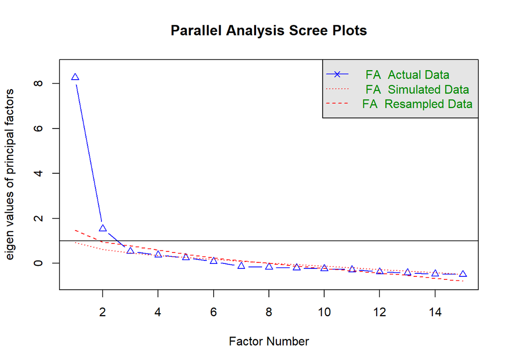

```
## Parallel analysis suggests that the number of factors =  2  and the number of components =  NA
```

```r
fa.parallel(misc_test2, n.obs=NULL, fm="uls", fa="fa", nfactors=1, main="Parallel Analysis Scree Plots", n.iter=20, error.bars=FALSE, se.bars=FALSE, SMC=FALSE, ylabel=NULL, show.legend=TRUE, sim=TRUE, quant=.95, cor="poly", use="pairwise", plot=TRUE, correct=.5) # suggest 2 factors
```

```r
fa(misc_test2, nfactors = 2, n.obs = NA, rotate = "quartimin", fm = "uls", cor = "poly")
```

```
## Factor Analysis using method =  uls
## Call: fa(r = misc_test2, nfactors = 2, n.obs = NA, rotate = "quartimin",
##     fm = "uls", cor = "poly")
## Standardized loadings (pattern matrix) based upon correlation matrix
##      ULS1  ULS2   h2    u2 com
## q42  0.72  0.14 0.65 0.350 1.1
## q43  0.81  0.02 0.67 0.328 1.0
## q44  0.87 -0.02 0.73 0.267 1.0
## q47  0.72 -0.24 0.38 0.620 1.2
## q48  0.47  0.21 0.38 0.618 1.4
## q50  1.00 -0.04 0.95 0.053 1.0
## q51  0.74  0.00 0.55 0.446 1.0
## q53  0.42  0.36 0.48 0.520 2.0
## q54  0.81  0.06 0.71 0.293 1.0
## q60  0.83  0.11 0.82 0.185 1.0
## q63  0.14  0.66 0.56 0.436 1.1
## q64  0.01  0.84 0.72 0.282 1.0
## q65  0.18  0.76 0.76 0.241 1.1
## q66 -0.04  0.96 0.89 0.115 1.0
## q67 -0.04  0.97 0.90 0.104 1.0
##
##                       ULS1 ULS2
## SS loadings           6.04 4.10
## Proportion Var        0.40 0.27
## Cumulative Var        0.40 0.68
## Proportion Explained  0.60 0.40
## Cumulative Proportion 0.60 1.00
##
##  With factor correlations of
##      ULS1 ULS2
## ULS1 1.00 0.58
## ULS2 0.58 1.00
##
## Mean item complexity =  1.1
## Test of the hypothesis that 2 factors are sufficient.
##
## The degrees of freedom for the null model are  105  and the objective function was  80.34 with Chi Square of  7083.03
## The degrees of freedom for the model are 76  and the objective function was  66.69
##
## The root mean square of the residuals (RMSR) is  0.08
## The df corrected root mean square of the residuals is  0.09
##
## The harmonic number of observations is  92 with the empirical chi square  109.23  with prob <  0.0075
## The total number of observations was  95  with Likelihood Chi Square =  5791.26  with prob <  0
##
## Tucker Lewis Index of factoring reliability =  -0.149
## RMSEA index =  0.89  and the 90 % confidence intervals are  0.875 0.914
## BIC =  5445.17
## Fit based upon off diagonal values = 0.98
```

# factor 1: parent as partner

42. …yo entiendo cómo funciona la escuela de mi joven.
43. …puedo comunicar mis preguntas y preocupaciones con los maestros y el personal de la escuela.
44. …puedo trabajar con la escuela para encontrar una solución positiva si surge un conflicto o un problema que involucre a mi joven en la escuela.
45. …parte de una comunidad con el personal de la escuela y los otros padres.
46. …tratado/a con respeto, sabiendo que mis opiniones son importantes.
47. … capaz de hablar con maestros o administradores sobre grandes preocupaciones relacionados con mi joven.
48. …dedicada/o en creando un ambiente exitoso para todos los jóvenes.
49. … esta escuela es un buen lugar para mi joven.
50. … maestros y administradores trabajan juntos para crear un ambiente seguro y acogedor para todos.

```r
partner <- parent_w1 %>%
  select(q42, q43, q44, q47, q48, q50, q51, q54, q60)

alpha(partner) #0.89
```

```
##
## Reliability analysis
## Call: alpha(x = partner)
##
##   raw_alpha std.alpha G6(smc) average_r S/N   ase mean   sd median_r
##       0.88      0.89     0.9      0.47   8 0.018  3.1 0.39     0.46
##
##     95% confidence boundaries
##          lower alpha upper
## Feldt     0.84  0.88  0.92
## Duhachek  0.85  0.88  0.92
##
##  Reliability if an item is dropped:
##     raw_alpha std.alpha G6(smc) average_r S/N alpha se var.r med.r
## q42      0.87      0.88    0.88      0.47 7.1    0.020 0.018  0.45
## q43      0.87      0.87    0.88      0.47 7.0    0.021 0.018  0.46
## q44      0.86      0.87    0.87      0.45 6.6    0.021 0.016  0.44
## q47      0.88      0.89    0.90      0.50 8.0    0.018 0.015  0.49
## q48      0.88      0.89    0.89      0.50 8.2    0.018 0.012  0.49
## q50      0.86      0.86    0.87      0.44 6.4    0.022 0.013  0.45
## q51      0.87      0.88    0.88      0.48 7.4    0.020 0.015  0.46
## q54      0.87      0.87    0.87      0.46 6.8    0.021 0.013  0.46
## q60      0.86      0.87    0.87      0.46 6.7    0.021 0.015  0.45
##
##  Item statistics
##      n raw.r std.r r.cor r.drop mean   sd
## q42 95  0.73  0.73  0.69   0.64  3.0 0.57
## q43 95  0.75  0.74  0.71   0.66  3.0 0.57
## q44 94  0.79  0.80  0.79   0.74  3.1 0.48
## q47 94  0.62  0.60  0.52   0.49  2.8 0.63
## q48 94  0.59  0.58  0.50   0.46  3.0 0.55
## q50 94  0.83  0.84  0.84   0.78  3.1 0.48
## q51 92  0.69  0.69  0.64   0.59  3.0 0.51
## q54 95  0.77  0.78  0.76   0.69  3.2 0.55
## q60 91  0.79  0.79  0.77   0.72  3.2 0.46
##
## Non missing response frequency for each item
##        1    2    3    4 miss
## q42 0.01 0.13 0.71 0.16 0.00
## q43 0.01 0.12 0.71 0.17 0.00
## q44 0.00 0.06 0.76 0.18 0.01
## q47 0.03 0.20 0.67 0.10 0.01
## q48 0.01 0.12 0.73 0.14 0.01
## q50 0.01 0.03 0.79 0.17 0.01
## q51 0.01 0.08 0.77 0.14 0.03
## q54 0.01 0.04 0.71 0.24 0.00
## q60 0.00 0.03 0.76 0.21 0.04
```

# factor 2: parent-teacher relationship

63. … puedo trabajar con un maestro para resolver cualquier problema que tenga mi joven en la escuela.
64. … que se preocupa por mi joven.
65. … quien está interesado en conocerme
66. … con quien me siento/a cómodo/a hablando sobre mi joven.
67. … de quien puedo hacer preguntas o hacer sugerencias sobre mi joven.

```r
par_teach_rel <- parent_w1 %>%
  select(q63, q64, q65, q66, q67)

alpha(par_teach_rel) #0.88
```

```
##
## Reliability analysis
## Call: alpha(x = par_teach_rel)
##
##   raw_alpha std.alpha G6(smc) average_r S/N  ase mean   sd median_r
##       0.88      0.88    0.88      0.59 7.1 0.02  3.1 0.42     0.56
##
##     95% confidence boundaries
##          lower alpha upper
## Feldt     0.83  0.88  0.91
## Duhachek  0.84  0.88  0.91
##
##  Reliability if an item is dropped:
##     raw_alpha std.alpha G6(smc) average_r S/N alpha se  var.r med.r
## q63      0.87      0.87    0.86      0.63 6.9    0.021 0.0169  0.62
## q64      0.86      0.86    0.85      0.61 6.3    0.022 0.0224  0.60
## q65      0.85      0.85    0.86      0.59 5.7    0.025 0.0193  0.56
## q66      0.83      0.83    0.80      0.55 4.9    0.028 0.0051  0.53
## q67      0.82      0.83    0.79      0.54 4.7    0.029 0.0057  0.54
##
##  Item statistics
##      n raw.r std.r r.cor r.drop mean   sd
## q63 92  0.73  0.75  0.65   0.60  3.2 0.45
## q64 94  0.75  0.78  0.69   0.64  3.2 0.46
## q65 90  0.84  0.81  0.74   0.70  3.0 0.56
## q66 94  0.89  0.87  0.87   0.79  3.1 0.58
## q67 93  0.90  0.88  0.88   0.82  3.1 0.50
##
## Non missing response frequency for each item
##        2    3    4 miss
## q63 0.03 0.77 0.20 0.03
## q64 0.02 0.74 0.23 0.01
## q65 0.14 0.69 0.17 0.05
## q66 0.14 0.66 0.20 0.01
## q67 0.10 0.75 0.15 0.02
```

# not used, new EFA

45. …estoy ayudando a mi joven hacer bien en la escuela.
46. …estoy ayudando a mi joven prepararse para sus futuras metas de educación y carrera.
47. …cómoda/o preguntando por un traductor y por materiales en español si los necesito.
48. …feliz de que mi joven asista a esta escuela.
49. …bienvenido/a en la escuela de mi joven.
50. … el personal de la escuela de mi joven está haciendo cosas buenas por ella / el.
51. … la gente en la escuela de mi joven es confiable.
52. … la escuela de mi joven hace un buen trabajo preparando a los jóvenes para sus futuros.
53. … puedo encontrar ayuda para mi joven si él / ella está batallando en una clase.
54. … los maestros de mi joven se preocupan por ella/el.
55. … hay muchas oportunidades para la involucración de los padres.
56. … puedo tener una conversación honesta y respetuosa sobre mi joven con su maestro.

```r
misc_test_3 <- parent_w1 %>%
  select(q45, q46, q49, q52, q53, q55, q56, q57, q58, q59, q61, q62)

fa(misc_test_3, n.obs = NA, rotate = "none", fm = "uls", cor = "poly") # looks good
```

```
## In smc, smcs < 0 were set to .0
## In smc, smcs < 0 were set to .0
## In smc, smcs < 0 were set to .0
```

```
## In factor.stats, I could not find the RMSEA upper bound . Sorry about that
```

```
## Factor Analysis using method =  uls
## Call: fa(r = misc_test_3, n.obs = NA, rotate = "none", fm = "uls",
##     cor = "poly")
## Standardized loadings (pattern matrix) based upon correlation matrix
##     ULS1   h2    u2 com
## q45 0.61 0.37 0.629   1
## q46 0.55 0.30 0.698   1
## q49 0.92 0.85 0.149   1
## q52 0.94 0.88 0.123   1
## q53 0.84 0.71 0.294   1
## q55 0.97 0.94 0.059   1
## q56 0.96 0.91 0.086   1
## q57 0.97 0.94 0.062   1
## q58 0.78 0.61 0.393   1
## q59 0.95 0.91 0.092   1
## q61 0.64 0.41 0.595   1
## q62 0.91 0.82 0.177   1
##
##                ULS1
## SS loadings    8.64
## Proportion Var 0.72
##
## Mean item complexity =  1
## Test of the hypothesis that 1 factor is sufficient.
##
## The degrees of freedom for the null model are  66  and the objective function was  78.53 with Chi Square of  7002.07
## The degrees of freedom for the model are 54  and the objective function was  63.49
##
## The root mean square of the residuals (RMSR) is  0.07
## The df corrected root mean square of the residuals is  0.08
##
## The harmonic number of observations is  93 with the empirical chi square  63.18  with prob <  0.18
## The total number of observations was  95  with Likelihood Chi Square =  5619.07  with prob <  0
##
## Tucker Lewis Index of factoring reliability =  0.012
## RMSEA index =  1.041  and the 90 % confidence intervals are  1.024 NA
## BIC =  5373.16
## Fit based upon off diagonal values = 0.99
```

```
## In smc, smcs < 0 were set to .0
```

```
## In smc, smcs < 0 were set to .0
## In smc, smcs < 0 were set to .0
```

```
## In smc, smcs < 0 were set to .0
## In smc, smcs < 0 were set to .0
```

```
## In smc, smcs < 0 were set to .0
## In smc, smcs < 0 were set to .0
```

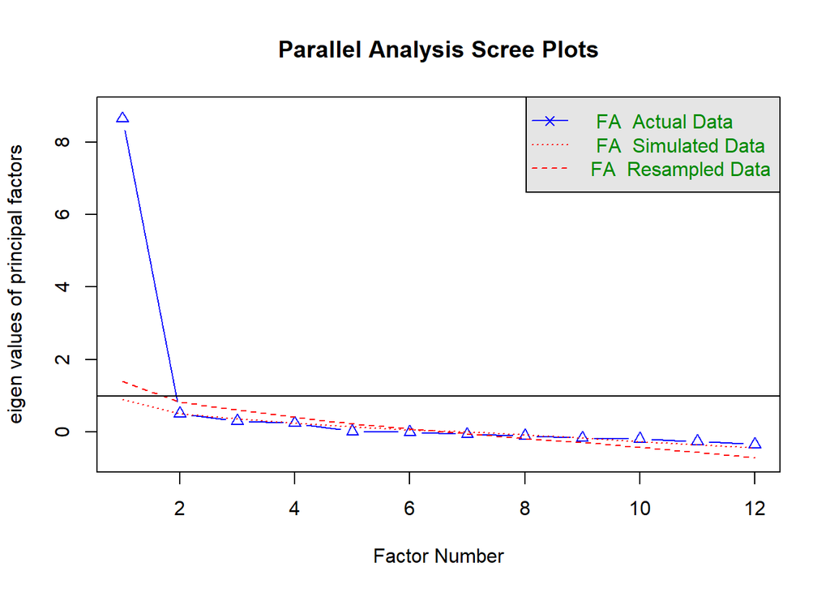

```
## Parallel analysis suggests that the number of factors =  1  and the number of components =  NA
```

```r
fa.parallel(misc_test_3, n.obs=NULL, fm="uls", fa="fa", nfactors=1, main="Parallel Analysis Scree Plots", n.iter=20, error.bars=FALSE, se.bars=FALSE, SMC=FALSE, ylabel=NULL, show.legend=TRUE, sim=TRUE, quant=.95, cor="poly", use="pairwise", plot=TRUE, correct=.5) # suggest 1 factor
```

# EFA again with other not included items

31. … conocer el personal y la administración de la escuela
32. … entender la diferencia entre obtener un GED, graduarse con un diploma estándar de la escuela secundaria, o con un diploma de una secundaria internacional o con un diploma de Bachillerato Internacional.
33. …entender la trayectoria hacia la preparación a la universidad y para una carrera
34. … asistir a la conferencia de padres y maestros cuando esté disponible.

```r
misc_test_4 <- parent_w1 %>%
  select(q36, q40, q41, q45, q46, q49, q52, q53, q55, q56, q57, q58, q59, q61, q62) # removed q31 bec low loading

fa(misc_test_4, n.obs = NA, rotate = "none", fm = "uls", cor = "poly") # looks good
```

```
## In smc, smcs < 0 were set to .0
## In smc, smcs < 0 were set to .0
## In smc, smcs < 0 were set to .0
```

```
## In factor.stats, I could not find the RMSEA upper bound . Sorry about that
```

```
## Factor Analysis using method =  uls
## Call: fa(r = misc_test_4, n.obs = NA, rotate = "none", fm = "uls",
##     cor = "poly")
## Standardized loadings (pattern matrix) based upon correlation matrix
##     ULS1   h2    u2 com
## q36 0.32 0.10 0.896   1
## q40 0.37 0.14 0.862   1
## q41 0.63 0.40 0.599   1
## q45 0.64 0.41 0.585   1
## q46 0.58 0.34 0.658   1
## q49 0.93 0.86 0.137   1
## q52 0.93 0.86 0.136   1
## q53 0.82 0.68 0.324   1
## q55 0.95 0.91 0.092   1
## q56 0.95 0.90 0.098   1
## q57 0.94 0.88 0.117   1
## q58 0.78 0.61 0.390   1
## q59 0.95 0.90 0.101   1
## q61 0.64 0.41 0.588   1
## q62 0.87 0.77 0.235   1
##
##                ULS1
## SS loadings    9.18
## Proportion Var 0.61
##
## Mean item complexity =  1
## Test of the hypothesis that 1 factor is sufficient.
##
## The degrees of freedom for the null model are  105  and the objective function was  100.8 with Chi Square of  8887.45
## The degrees of freedom for the model are 90  and the objective function was  85.81
##
## The root mean square of the residuals (RMSR) is  0.12
## The df corrected root mean square of the residuals is  0.13
##
## The harmonic number of observations is  93 with the empirical chi square  282.71  with prob <  9.1e-22
## The total number of observations was  95  with Likelihood Chi Square =  7508.68  with prob <  0
##
## Tucker Lewis Index of factoring reliability =  0.007
## RMSEA index =  0.931  and the 90 % confidence intervals are  0.919 NA
## BIC =  7098.83
## Fit based upon off diagonal values = 0.96
```

```
## In smc, smcs < 0 were set to .0
```

```
## In smc, smcs < 0 were set to .0
## In smc, smcs < 0 were set to .0
```

```
## In smc, smcs < 0 were set to .0
## In smc, smcs < 0 were set to .0
```

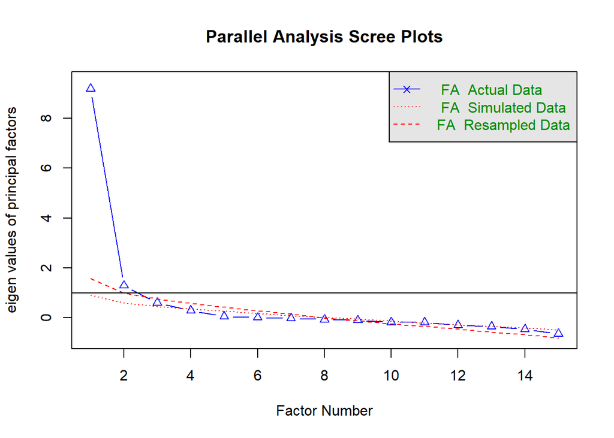

```
## Parallel analysis suggests that the number of factors =  3  and the number of components =  NA
```

```r
fa.parallel(misc_test_4, n.obs=NULL, fm="uls", fa="fa", nfactors=1, main="Parallel Analysis Scree Plots", n.iter=20, error.bars=FALSE, se.bars=FALSE, SMC=FALSE, ylabel=NULL, show.legend=TRUE, sim=TRUE, quant=.95, cor="poly", use="pairwise", plot=TRUE, correct=.5) # suggest 3 factors
```

```r
fa(misc_test_4, nfactors = 3, n.obs = NA, rotate = "quartimin", fm = "uls", cor = "poly")
```

```
## In smc, smcs < 0 were set to .0
## In smc, smcs < 0 were set to .0
## In smc, smcs < 0 were set to .0
```

```
## In factor.stats, I could not find the RMSEA upper bound . Sorry about that
```

```
## Factor Analysis using method =  uls
## Call: fa(r = misc_test_4, nfactors = 3, n.obs = NA, rotate = "quartimin",
##     fm = "uls", cor = "poly")
## Standardized loadings (pattern matrix) based upon correlation matrix
##      ULS1  ULS2  ULS3   h2    u2 com
## q36  0.01  0.86 -0.06 0.73 0.270 1.0
## q40 -0.06  0.78  0.17 0.65 0.352 1.1
## q41  0.12  0.02  0.79 0.76 0.244 1.0
## q45  0.13  0.30  0.61 0.64 0.356 1.6
## q46  0.20  0.53  0.26 0.55 0.450 1.8
## q49  0.65  0.08  0.38 0.89 0.107 1.6
## q52  0.73 -0.08  0.37 0.94 0.059 1.5
## q53  0.93 -0.18 -0.01 0.80 0.201 1.1
## q55  0.88 -0.09  0.21 0.97 0.034 1.1
## q56  0.92  0.07  0.02 0.92 0.080 1.0
## q57  0.92  0.13 -0.02 0.91 0.093 1.0
## q58  0.76  0.09 -0.01 0.62 0.376 1.0
## q59  0.89  0.23 -0.03 0.93 0.067 1.1
## q61  0.64  0.39 -0.22 0.58 0.420 1.9
## q62  1.02 -0.15 -0.07 0.91 0.094 1.1
##
##                       ULS1 ULS2 ULS3
## SS loadings           7.69 2.21 1.90
## Proportion Var        0.51 0.15 0.13
## Cumulative Var        0.51 0.66 0.79
## Proportion Explained  0.65 0.19 0.16
## Cumulative Proportion 0.65 0.84 1.00
##
##  With factor correlations of
##      ULS1 ULS2 ULS3
## ULS1 1.00 0.29 0.54
## ULS2 0.29 1.00 0.17
## ULS3 0.54 0.17 1.00
##
## Mean item complexity =  1.3
## Test of the hypothesis that 3 factors are sufficient.
##
## The degrees of freedom for the null model are  105  and the objective function was  100.8 with Chi Square of  8887.45
## The degrees of freedom for the model are 63  and the objective function was  81.96
##
## The root mean square of the residuals (RMSR) is  0.04
## The df corrected root mean square of the residuals is  0.06
##
## The harmonic number of observations is  93 with the empirical chi square  36.31  with prob <  1
## The total number of observations was  95  with Likelihood Chi Square =  7062.65  with prob <  0
##
## Tucker Lewis Index of factoring reliability =  -0.36
## RMSEA index =  1.081  and the 90 % confidence intervals are  1.066 NA
## BIC =  6775.75
## Fit based upon off diagonal values = 1
```